# Assignment 3

57584800 WANG Guanzhang 15/02/2023 20:00

```python
import pandas as pd
import matplotlib.pyplot as plt
data = pd.read_csv('iris.txt',header=None)
data.columns = ['sepal length', 'sepal width', 'petal length', 'petal width', 'class']
```

## 1. (20 points) Use pandas library to explore descriptive statistics of attribute 'sepal length' and 'sepal width' and their correlation.

hint: you may use tool [pandas.describe](https://pandas.pydata.org/docs/reference/api/pandas.DataFrame.describe.html).

```python
print("The descriptive statistics of speal length:\n",data['sepal length'].describe())
print("----------")
print("The descriptive statistics of speal width:\n",data['sepal width'].describe())
print("----------")
print("The correlation between them is:",data['sepal length'].corr(data['sepal width'], method='pearson'))
```

```
The descriptive statistics of speal length:
 count    150.000000
mean       5.843333
std        0.828066
min        4.300000
25%        5.100000
50%        5.800000
75%        6.400000
max        7.900000
Name: sepal length, dtype: float64
----------
The descriptive statistics of speal width:
 count    150.000000
mean       3.054000
std        0.433594
min        2.000000
25%        2.800000
50%        3.000000
75%        3.300000
max        4.400000
Name: sepal width, dtype: float64
----------
The correlation between them is: -0.10936924995064937
```

## 2. (20 points) Change the bin of histogram from 10 to 15, plot your new histogram. What is the difference between histograms with different bin number?

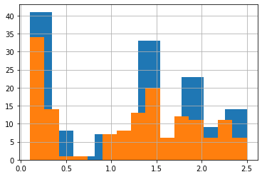

```python
data['petal width'].hist(bins=10)
data['petal width'].hist(bins=15)
```

With the bins increase, the x-axis's range has been divided more detailed

## 3. (20 points) What is the 50 percentile, 75 percentile of petal length?

```python
print("The 50 percentile of the petal length:", data['petal length'].quantile(0.5))
print("The 75 percentile of the petal length:", data['petal length'].quantile(0.75))
```

```
The 50 percentile of the petal length: 4.35
The 75 percentile of the petal length: 5.1
```

## 4. (20 points) Choose another pair of attribute to do the scatter plot. (please do not use the pair of sepal width - sepal length.

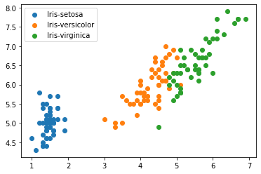

```python
groups = data.groupby("class")
for name, group in groups:
    plt.scatter(group['petal length'],group['sepal length'], marker="o", label=name)
plt.legend()
plt.show()
```

## 5. (20 points) According to your scatter plot, can you provide some hints for classifying the different classes of Iris?

According to the length of the petal and sepal, we can identify that the setosa has both the shortest length, versicolor has a speal length between 5.0 ~ 7.0 with a petal length range from 3 ~ 5, and the virginica has a more widely speal length area from 5.5 ~ 8.0 with petal length from 4 ~ 7